# Travel Package Purchase Prediction

## Background

Visit With Us is looking to grow and acquire new customers. They are going to be offering a new package, Wellness Tourism Package. This package allows the travelor to maintain or kickstart a healthy lifestyle, and increase well-being. They have hired me to analyze the packages.

## Key Question to Answer

Which customer is going to purchase the travel packages?

## Dataset

#### The lines below give a brief definition of each variable in the dataset:

CustomerID: Unique customer ID

ProdTaken: Whether the customer has purchased a package or not (0: No, 1: Yes)

Age: Age of customer

TypeofContact: How customer was contacted (Company Invited or Self Inquiry)

CityTier: City tier depends on the development of a city, population, facilities, and living standards. The categories are ordered i.e. Tier 1 > Tier 2 > Tier 3

DurationOfPitch: Duration of the pitch by a salesperson to the customer

Occupation: Occupation of customer

Gender: Gender of customer

NumberOfPersonVisiting: Total number of persons planning to take the trip with the customer

PreferredPropertyStar: Preferred hotel property rating by customer

MaritalStatus: Marital status of customer

NumberOfTrips: Average number of trips in a year by customer

Passport: The customer has a passport or not (0: No, 1: Yes)

OwnCar: Whether the customers own a car or not (0: No, 1: Yes)

NumberOfChildrenVisiting: Total number of children with age less than 5 planning to take the trip with the customer

Designation: Designation of the customer in the current organization

MonthlyIncome: Gross monthly income of the customer

```python
# To help make our code look less cluttered, this removes the warnings that pop up.
import warnings

warnings.filterwarnings("ignore")
```

```python
# Importing the packages for this project

%load_ext nb_black

import numpy as np
import pandas as pd
import matplotlib.pyplot as plt
import seaborn as sns
import scipy.stats as stats

%matplotlib inline


# Splitting data in train and test splits
from sklearn.model_selection import train_test_split

# To build model for prediction
import statsmodels.stats.api as sms
from statsmodels.stats.outliers_influence import variance_inflation_factor
import statsmodels.api as sm
from statsmodels.tools.tools import add_constant
from sklearn.linear_model import LogisticRegression
from sklearn.tree import DecisionTreeClassifier
from sklearn import tree

# To tune
from sklearn.model_selection import GridSearchCV

# To get diferent metrics
from sklearn.metrics import (
    f1_score,
    accuracy_score,
    recall_score,
    precision_score,
    confusion_matrix,
    roc_auc_score,
    plot_confusion_matrix,
    precision_recall_curve,
    roc_curve,
    make_scorer,
)

# Bagging and Boosting
from sklearn import metrics
from sklearn.ensemble import BaggingClassifier, RandomForestClassifier
from sklearn.tree import DecisionTreeRegressor
from sklearn.ensemble import (
    BaggingRegressor,
    RandomForestRegressor,
    GradientBoostingRegressor,
    AdaBoostRegressor,
    StackingRegressor,
)
from xgboost import XGBRegressor
from sklearn.ensemble import AdaBoostClassifier, GradientBoostingClassifier
from xgboost import XGBClassifier
```

```python
# Reading our dataset titled "Tourism.xlsx".
file = pd.read_excel("Tourism.xlsx", sheet_name="Tourism")

# Making a copy of the dataset, so I am not making any changes to the original file.
data = file.copy()
```

```python
# Viewing the first 5 rows of the dataset
data.head(20)
```

|  | CustomerID | ProdTaken | Age | TypeofContact | CityTier | DurationOfPitch | Occupation | Gender | NumberOfPersonVisiting | NumberOfFollowups | ProductPitched | PreferredPropertyStar | MaritalStatus | NumberOfTrips | Passport | PitchSatisfactionScore | OwnCar | NumberOfChildrenVisiting | Designation | MonthlyIncome |
| --- | --- | --- | --- | --- | --- | --- | --- | --- | --- | --- | --- | --- | --- | --- | --- | --- | --- | --- | --- | --- |
| 0 | 200000 | 1 | 41.0 | Self Enquiry | 3 | 6.0 | Salaried | Female | 3 | 3.0 | Deluxe | 3.0 | Single | 1.0 | 1 | 2 | 1 | 0.0 | Manager | 20993.0 |
| 1 | 200001 | 0 | 49.0 | Company Invited | 1 | 14.0 | Salaried | Male | 3 | 4.0 | Deluxe | 4.0 | Divorced | 2.0 | 0 | 3 | 1 | 2.0 | Manager | 20130.0 |
| 2 | 200002 | 1 | 37.0 | Self Enquiry | 1 | 8.0 | Free Lancer | Male | 3 | 4.0 | Basic | 3.0 | Single | 7.0 | 1 | 3 | 0 | 0.0 | Executive | 17090.0 |
| 3 | 200003 | 0 | 33.0 | Company Invited | 1 | 9.0 | Salaried | Female | 2 | 3.0 | Basic | 3.0 | Divorced | 2.0 | 1 | 5 | 1 | 1.0 | Executive | 17909.0 |
| 4 | 200004 | 0 | NaN | Self Enquiry | 1 | 8.0 | Small Business | Male | 2 | 3.0 | Basic | 4.0 | Divorced | 1.0 | 0 | 5 | 1 | 0.0 | Executive | 18468.0 |
| 5 | 200005 | 0 | 32.0 | Company Invited | 1 | 8.0 | Salaried | Male | 3 | 3.0 | Basic | 3.0 | Single | 1.0 | 0 | 5 | 1 | 1.0 | Executive | 18068.0 |
| 6 | 200006 | 0 | 59.0 | Self Enquiry | 1 | 9.0 | Small Business | Female | 2 | 2.0 | Basic | 5.0 | Divorced | 5.0 | 1 | 2 | 1 | 1.0 | Executive | 17670.0 |
| 7 | 200007 | 0 | 30.0 | Self Enquiry | 1 | 30.0 | Salaried | Male | 3 | 3.0 | Basic | 3.0 | Married | 2.0 | 0 | 2 | 0 | 1.0 | Executive | 17693.0 |
| 8 | 200008 | 0 | 38.0 | Company Invited | 1 | 29.0 | Salaried | Male | 2 | 4.0 | Standard | 3.0 | Unmarried | 1.0 | 0 | 3 | 0 | 0.0 | Senior Manager | 24526.0 |
| 9 | 200009 | 0 | 36.0 | Self Enquiry | 1 | 33.0 | Small Business | Male | 3 | 3.0 | Deluxe | 3.0 | Divorced | 7.0 | 0 | 3 | 1 | 0.0 | Manager | 20237.0 |
| 10 | 200010 | 0 | 35.0 | Self Enquiry | 1 | 22.0 | Small Business | Male | 2 | 2.0 | Basic | 4.0 | Divorced | 1.0 | 0 | 3 | 1 | 1.0 | Executive | 17426.0 |
| 11 | 200011 | 0 | NaN | Self Enquiry | 1 | 21.0 | Salaried | Female | 2 | 4.0 | Deluxe | 3.0 | Single | 1.0 | 1 | 3 | 0 | 0.0 | Manager | NaN |
| 12 | 200012 | 0 | 31.0 | Self Enquiry | 1 | 32.0 | Salaried | Male | 2 | 3.0 | Basic | 3.0 | Married | 2.0 | 0 | 3 | 0 | 1.0 | Executive | 17911.0 |
| 13 | 200013 | 0 | 34.0 | Self Enquiry | 1 | 25.0 | Small Business | Male | 3 | 3.0 | Basic | 3.0 | Married | 1.0 | 0 | 3 | 0 | 2.0 | Executive | 17661.0 |
| 14 | 200014 | 1 | 28.0 | Self Enquiry | 1 | 30.0 | Salaried | Male | 2 | 4.0 | Basic | 3.0 | Single | 6.0 | 1 | 2 | 0 | 0.0 | Executive | 17028.0 |
| 15 | 200015 | 0 | 29.0 | Self Enquiry | 1 | 27.0 | Salaried | Female | 2 | 2.0 | Standard | 5.0 | Married | 2.0 | 0 | 5 | 1 | 1.0 | Senior Manager | 24980.0 |
| 16 | 200016 | 0 | 32.0 | Self Enquiry | 1 | 11.0 | Salaried | Male | 3 | 2.0 | Basic | 4.0 | Married | 1.0 | 1 | 2 | 1 | 0.0 | Executive | 18298.0 |
| 17 | 200017 | 0 | 22.0 | Company Invited | 1 | 22.0 | Small Business | Male | 3 | 2.0 | Basic | 3.0 | Married | 2.0 | 1 | 3 | 0 | 0.0 | Executive | 17935.0 |
| 18 | 200018 | 0 | 53.0 | Self Enquiry | 3 | 8.0 | Salaried | Female | 3 | 4.0 | Super Deluxe | 3.0 | Divorced | 3.0 | 0 | 3 | 1 | 0.0 | AVP | 30427.0 |
| 19 | 200019 | 0 | NaN | Self Enquiry | 1 | 8.0 | Salaried | Male | 2 | 3.0 | Basic | 3.0 | Single | 6.0 | 1 | 4 | 0 | 1.0 | Executive | NaN |

#### Observations

```python
# Viewing the last 5 rows of the dataset
data.tail(20)
```

|  | CustomerID | ProdTaken | Age | TypeofContact | CityTier | DurationOfPitch | Occupation | Gender | NumberOfPersonVisiting | NumberOfFollowups | ProductPitched | PreferredPropertyStar | MaritalStatus | NumberOfTrips | Passport | PitchSatisfactionScore | OwnCar | NumberOfChildrenVisiting | Designation | MonthlyIncome |
| --- | --- | --- | --- | --- | --- | --- | --- | --- | --- | --- | --- | --- | --- | --- | --- | --- | --- | --- | --- | --- |
| 4868 | 204868 | 1 | 43.0 | Company Invited | 2 | 15.0 | Salaried | Female | 4 | 5.0 | Basic | 3.0 | Married | NaN | 0 | 5 | 1 | 2.0 | Executive | 36539.0 |
| 4869 | 204869 | 1 | 56.0 | Self Enquiry | 3 | 16.0 | Small Business | Female | 3 | 6.0 | Basic | 4.0 | Single | NaN | 0 | 1 | 1 | 2.0 | Executive | 37865.0 |
| 4870 | 204870 | 1 | 57.0 | Self Enquiry | 3 | 23.0 | Salaried | Female | 4 | 4.0 | Standard | NaN | Single | 4.0 | 1 | 5 | 1 | 3.0 | Senior Manager | 38395.0 |
| 4871 | 204871 | 1 | 41.0 | Self Enquiry | 3 | 23.0 | Small Business | Male | 4 | 4.0 | Standard | 3.0 | Married | 4.0 | 0 | 5 | 0 | 2.0 | Senior Manager | 22222.0 |
| 4872 | 204872 | 1 | 35.0 | Company Invited | 1 | 24.0 | Large Business | Male | 3 | 5.0 | Basic | 3.0 | Married | 2.0 | 1 | 5 | 1 | 2.0 | Executive | 27178.0 |
| 4873 | 204873 | 1 | 41.0 | Self Enquiry | 3 | 14.0 | Small Business | Male | 3 | 4.0 | Basic | 4.0 | Unmarried | 3.0 | 0 | 5 | 0 | 1.0 | Executive | 23339.0 |
| 4874 | 204874 | 1 | 42.0 | Self Enquiry | 1 | 15.0 | Small Business | Female | 4 | 4.0 | Basic | 5.0 | Married | 3.0 | 1 | 3 | 0 | 3.0 | Executive | 22781.0 |
| 4875 | 204875 | 1 | 36.0 | Company Invited | 1 | 8.0 | Small Business | Male | 4 | 4.0 | Basic | 4.0 | Married | 3.0 | 1 | 3 | 1 | 1.0 | Executive | 22927.0 |
| 4876 | 204876 | 1 | 52.0 | Self Enquiry | 3 | 34.0 | Salaried | Male | 3 | 4.0 | Deluxe | 3.0 | Single | 3.0 | 1 | 5 | 1 | 2.0 | Manager | 32704.0 |
| 4877 | 204877 | 1 | 39.0 | Company Invited | 1 | 16.0 | Salaried | Male | 4 | 4.0 | Deluxe | 5.0 | Married | 6.0 | 0 | 3 | 0 | 3.0 | Manager | 25571.0 |
| 4878 | 204878 | 1 | 35.0 | Self Enquiry | 1 | 17.0 | Small Business | Male | 3 | 4.0 | Deluxe | 5.0 | Unmarried | 3.0 | 0 | 4 | 0 | 1.0 | Manager | 24803.0 |
| 4879 | 204879 | 1 | 26.0 | Self Enquiry | 2 | 27.0 | Small Business | Female | 4 | 4.0 | Basic | 4.0 | Married | 2.0 | 1 | 3 | 0 | 2.0 | Executive | 22347.0 |
| 4880 | 204880 | 1 | 59.0 | Self Enquiry | 1 | 28.0 | Small Business | Female | 4 | 4.0 | Deluxe | 4.0 | Married | 6.0 | 0 | 3 | 1 | 2.0 | Manager | 28686.0 |
| 4881 | 204881 | 1 | 41.0 | Self Enquiry | 2 | 25.0 | Salaried | Male | 3 | 2.0 | Basic | 5.0 | Married | 2.0 | 0 | 1 | 1 | 2.0 | Executive | 21065.0 |
| 4882 | 204882 | 1 | 37.0 | Self Enquiry | 2 | 20.0 | Salaried | Male | 3 | 5.0 | Basic | 5.0 | Married | 6.0 | 1 | 5 | 1 | 2.0 | Executive | 23317.0 |
| 4883 | 204883 | 1 | 49.0 | Self Enquiry | 3 | 9.0 | Small Business | Male | 3 | 5.0 | Deluxe | 4.0 | Unmarried | 2.0 | 1 | 1 | 1 | 1.0 | Manager | 26576.0 |
| 4884 | 204884 | 1 | 28.0 | Company Invited | 1 | 31.0 | Salaried | Male | 4 | 5.0 | Basic | 3.0 | Single | 3.0 | 1 | 3 | 1 | 2.0 | Executive | 21212.0 |
| 4885 | 204885 | 1 | 52.0 | Self Enquiry | 3 | 17.0 | Salaried | Female | 4 | 4.0 | Standard | 4.0 | Married | 7.0 | 0 | 1 | 1 | 3.0 | Senior Manager | 31820.0 |
| 4886 | 204886 | 1 | 19.0 | Self Enquiry | 3 | 16.0 | Small Business | Male | 3 | 4.0 | Basic | 3.0 | Single | 3.0 | 0 | 5 | 0 | 2.0 | Executive | 20289.0 |
| 4887 | 204887 | 1 | 36.0 | Self Enquiry | 1 | 14.0 | Salaried | Male | 4 | 4.0 | Basic | 4.0 | Unmarried | 3.0 | 1 | 3 | 1 | 2.0 | Executive | 24041.0 |

```python
# Looking at the shape of the dataset
data.shape
```

```
(4888, 20)
```

#### Observations

There are 4888 rows and 20 columns in the dataset.

```python
# Looking at the data types of our variables
data.info()
```

```
<class 'pandas.core.frame.DataFrame'>
RangeIndex: 4888 entries, 0 to 4887
Data columns (total 20 columns):
 #   Column                    Non-Null Count  Dtype
---  ------                    --------------  -----
 0   CustomerID                4888 non-null   int64
 1   ProdTaken                 4888 non-null   int64
 2   Age                       4662 non-null   float64
 3   TypeofContact             4863 non-null   object
 4   CityTier                  4888 non-null   int64
 5   DurationOfPitch           4637 non-null   float64
 6   Occupation                4888 non-null   object
 7   Gender                    4888 non-null   object
 8   NumberOfPersonVisiting    4888 non-null   int64
 9   NumberOfFollowups         4843 non-null   float64
 10  ProductPitched            4888 non-null   object
 11  PreferredPropertyStar     4862 non-null   float64
 12  MaritalStatus             4888 non-null   object
 13  NumberOfTrips             4748 non-null   float64
 14  Passport                  4888 non-null   int64
 15  PitchSatisfactionScore    4888 non-null   int64
 16  OwnCar                    4888 non-null   int64
 17  NumberOfChildrenVisiting  4822 non-null   float64
 18  Designation               4888 non-null   object
 19  MonthlyIncome             4655 non-null   float64
dtypes: float64(7), int64(7), object(6)
memory usage: 763.9+ KB
```

```python
# Let's drop the CustomerID column, as it is just an index column
data.drop(["CustomerID"], axis=1, inplace=True)
```

```python
# Checking that CustomerID is removed
data.info()
```

```
<class 'pandas.core.frame.DataFrame'>
RangeIndex: 4888 entries, 0 to 4887
Data columns (total 19 columns):
 #   Column                    Non-Null Count  Dtype
---  ------                    --------------  -----
 0   ProdTaken                 4888 non-null   int64
 1   Age                       4662 non-null   float64
 2   TypeofContact             4863 non-null   object
 3   CityTier                  4888 non-null   int64
 4   DurationOfPitch           4637 non-null   float64
 5   Occupation                4888 non-null   object
 6   Gender                    4888 non-null   object
 7   NumberOfPersonVisiting    4888 non-null   int64
 8   NumberOfFollowups         4843 non-null   float64
 9   ProductPitched            4888 non-null   object
 10  PreferredPropertyStar     4862 non-null   float64
 11  MaritalStatus             4888 non-null   object
 12  NumberOfTrips             4748 non-null   float64
 13  Passport                  4888 non-null   int64
 14  PitchSatisfactionScore    4888 non-null   int64
 15  OwnCar                    4888 non-null   int64
 16  NumberOfChildrenVisiting  4822 non-null   float64
 17  Designation               4888 non-null   object
 18  MonthlyIncome             4655 non-null   float64
dtypes: float64(7), int64(6), object(6)
memory usage: 725.7+ KB
```

#### Observations

CustomerID is now removed from the dataset

```python
# Let's get an understanding on missing values in our dataset
data.isnull().sum().sort_values(ascending=False)
```

```
DurationOfPitch             251
MonthlyIncome               233
Age                         226
NumberOfTrips               140
NumberOfChildrenVisiting     66
NumberOfFollowups            45
PreferredPropertyStar        26
TypeofContact                25
Gender                        0
CityTier                      0
Occupation                    0
ProductPitched                0
NumberOfPersonVisiting        0
Designation                   0
MaritalStatus                 0
Passport                      0
PitchSatisfactionScore        0
OwnCar                        0
ProdTaken                     0
dtype: int64
```

```python
# Cleaning the data. Looking for any blank entries in the dataset
data = data.dropna()
```

```python
# Looking at the shape of the dataset
data.shape
```

```
(4128, 19)
```

#### Observations

I removed the blanks from the dataset.

```python
# Let's check the options for Genders, I noticed some issues when looking at the dateset.
data["Gender"].unique()
```

```
array(['Female', 'Male', 'Fe Male'], dtype=object)
```

#### Observations

It appears that some entries are errors, and are listed as "Fe Male". Let's clean this, and convert to Female.

```python
# Let's convert "Fe Male" to "Female"
data["Gender"] = data["Gender"].replace(["Fe Male"], "Female")
```

```python
# Let's now convert some datatypes
data["ProdTaken"] = data["ProdTaken"].astype("bool")
data["Age"] = data["Age"].astype("int64")
data["TypeofContact"] = data["TypeofContact"].astype("category")
data["CityTier"] = data["CityTier"].astype("category")
data["Occupation"] = data["Occupation"].astype("category")
data["Gender"] = data["Gender"].astype("category")
data["ProductPitched"] = data["ProductPitched"].astype("category")
data["PreferredPropertyStar"] = data["PreferredPropertyStar"].astype("category")
data["MaritalStatus"] = data["MaritalStatus"].astype("category")
data["MaritalStatus"] = data["MaritalStatus"].astype("category")
data["Passport"] = data["Passport"].astype("bool")
data["PitchSatisfactionScore"] = data["PitchSatisfactionScore"].astype("category")
data["OwnCar"] = data["OwnCar"].astype("bool")
data["Designation"] = data["Designation"].astype("category")
```

```python
# Looking at the data types of our variables
data.info()
```

```
<class 'pandas.core.frame.DataFrame'>
Int64Index: 4128 entries, 0 to 4887
Data columns (total 19 columns):
 #   Column                    Non-Null Count  Dtype
---  ------                    --------------  -----
 0   ProdTaken                 4128 non-null   bool
 1   Age                       4128 non-null   int64
 2   TypeofContact             4128 non-null   category
 3   CityTier                  4128 non-null   category
 4   DurationOfPitch           4128 non-null   float64
 5   Occupation                4128 non-null   category
 6   Gender                    4128 non-null   category
 7   NumberOfPersonVisiting    4128 non-null   int64
 8   NumberOfFollowups         4128 non-null   float64
 9   ProductPitched            4128 non-null   category
 10  PreferredPropertyStar     4128 non-null   category
 11  MaritalStatus             4128 non-null   category
 12  NumberOfTrips             4128 non-null   float64
 13  Passport                  4128 non-null   bool
 14  PitchSatisfactionScore    4128 non-null   category
 15  OwnCar                    4128 non-null   bool
 16  NumberOfChildrenVisiting  4128 non-null   float64
 17  Designation               4128 non-null   category
 18  MonthlyIncome             4128 non-null   float64
dtypes: bool(3), category(9), float64(5), int64(2)
memory usage: 307.7 KB
```

#### Observations

Our datatypes are now in order

```python
# Giving us some basic numbers in regards to our dataset. ".T" is to transpose the data.
data.describe().T
```

|  | count | mean | std | min | 25% | 50% | 75% | max |
| --- | --- | --- | --- | --- | --- | --- | --- | --- |
| Age | 4128.0 | 37.231831 | 9.174521 | 18.0 | 31.0 | 36.0 | 43.0 | 61.0 |
| DurationOfPitch | 4128.0 | 15.584787 | 8.398142 | 5.0 | 9.0 | 14.0 | 20.0 | 127.0 |
| NumberOfPersonVisiting | 4128.0 | 2.949370 | 0.718818 | 1.0 | 2.0 | 3.0 | 3.0 | 5.0 |
| NumberOfFollowups | 4128.0 | 3.741521 | 1.006786 | 1.0 | 3.0 | 4.0 | 4.0 | 6.0 |
| NumberOfTrips | 4128.0 | 3.295300 | 1.856300 | 1.0 | 2.0 | 3.0 | 4.0 | 22.0 |
| NumberOfChildrenVisiting | 4128.0 | 1.223595 | 0.852685 | 0.0 | 1.0 | 1.0 | 2.0 | 3.0 |
| MonthlyIncome | 4128.0 | 23178.464147 | 4506.614622 | 1000.0 | 20751.0 | 22418.0 | 25301.0 | 98678.0 |

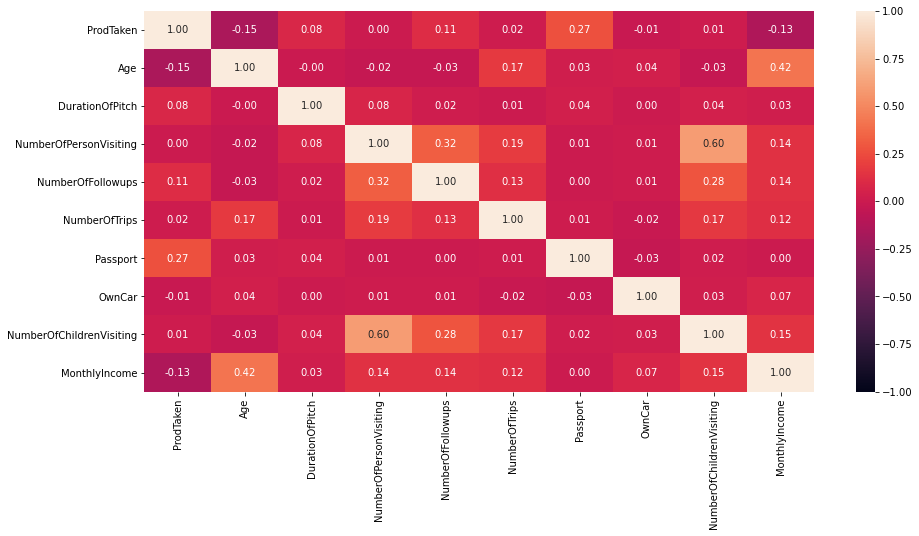

```python
# Heatmap of variable correlation
plt.figure(figsize=(15, 7))
sns.heatmap(data.corr(), annot=True, vmin=-1, vmax=1, fmt=".2f")
plt.show()
```

## EDA

```python
# Defining a function to show percentage on bars for our countplots
def percent(plot, feature):
    """
    plot
    feature: categorical feature
    the function won't work if a column is passed in hue parameter
    """
    total = len(feature)
    for p in ax.patches:
        percentage = "{:.1f}%".format(100 * p.get_height() / total)
        x = p.get_x() + p.get_width() / 2 - 0.05
        y = p.get_y() + p.get_height()
        ax.annotate(percentage, (x, y), size=12)
    plt.show()


# Defining a histogram function to show us outliers and boxplot, as well as median and mean vlines
def histogram_boxplot(feature, figsize=(15, 10), bins=None):
    """Boxplot and histogram combined
    feature: 1-d feature array
    figsize: size of fig (default (9,8))
    bins: number of bins (default None / auto)
    """
    f2, (ax_box2, ax_hist2) = plt.subplots(
        nrows=2,
        sharex=True,
        gridspec_kw={"height_ratios": (0.25, 0.75)},
        figsize=figsize,
    )
    sns.boxplot(feature, ax=ax_box2, showmeans=True, color="violet")
    sns.distplot(
        feature, kde=F, ax=ax_hist2, bins=bins, palette="winter"
    ) if bins else sns.distplot(feature, kde=False, ax=ax_hist2)
    ax_hist2.axvline(np.mean(feature), color="green", linestyle="--")
    ax_hist2.axvline(np.median(feature), color="black", linestyle="-")
```

### Univariate Analysis

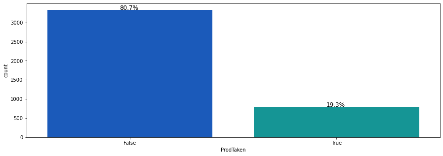

```python
# Countplot of ProdTaken
plt.figure(figsize=(15, 5))
ax = sns.countplot(data["ProdTaken"], palette="winter")
percent(ax, data["ProdTaken"])
```

#### Observations

I see roughly a 20% average conversion rate in the dataset.

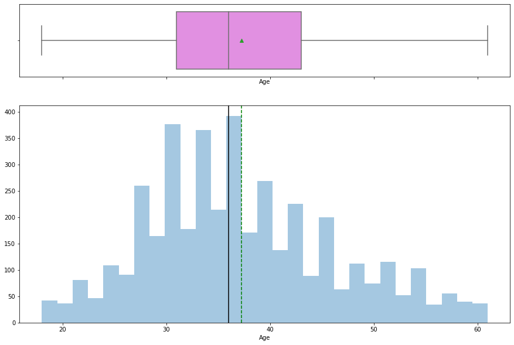

```python
# Histogram showing Age
histogram_boxplot(data["Age"])
```

#### Observations

There is a right skew with our mean being higher than the median.

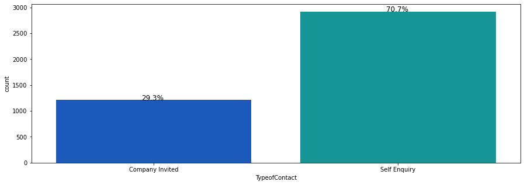

```python
# Countplot of TypeofContact
plt.figure(figsize=(15, 5))
ax = sns.countplot(data["TypeofContact"], palette="winter")
percent(ax, data["TypeofContact"])
```

#### Observations

I see that 70% of the dataset is Self Inquiry for TypeOfContact

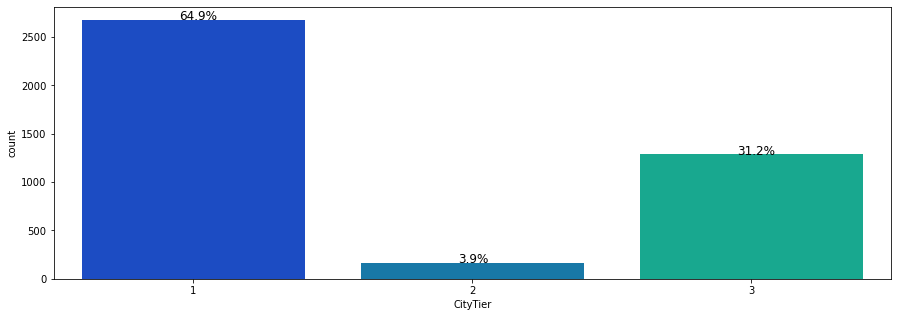

```python
# Countplot of CityTier
plt.figure(figsize=(15, 5))
ax = sns.countplot(data["CityTier"], palette="winter")
percent(ax, data["CityTier"])
```

#### Observations

CityTier 2 is quite rare, occupying 3.9% of the dataset. CityTier 1 is the majority, taking up about two-thirds of the dataset.

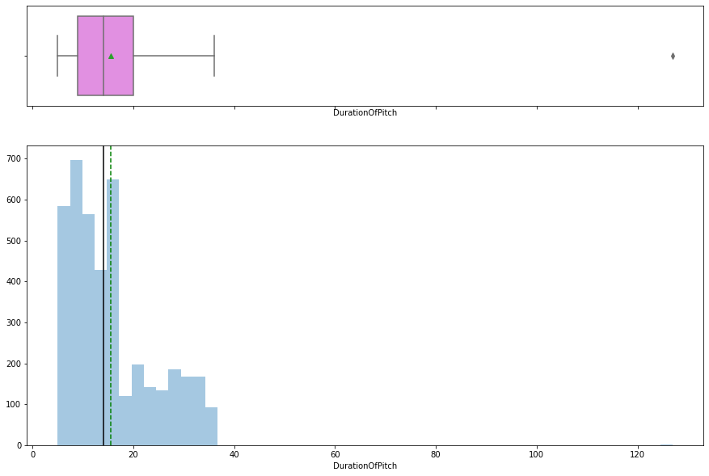

```python
# Histogram showing DurationOfPitch
histogram_boxplot(data["DurationOfPitch"])
```

#### Observations

There is an outlier here that will be remedied later. The mean is greater than the median, indicating a right skew in the data.

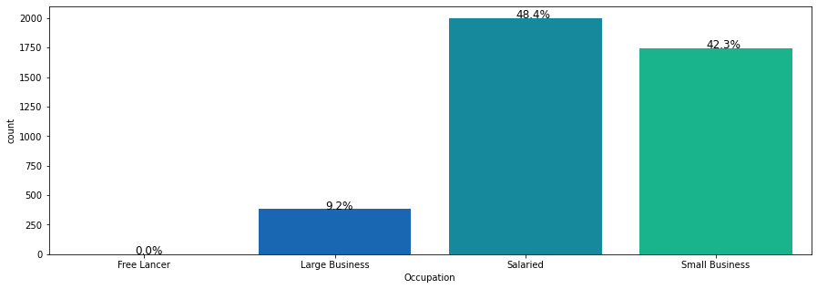

```python
# Countplot of Occupation
plt.figure(figsize=(15, 5))
ax = sns.countplot(data["Occupation"], palette="winter")
percent(ax, data["Occupation"])
```

#### Observations

Salaried and Small Business take up a large majority of the dataset.

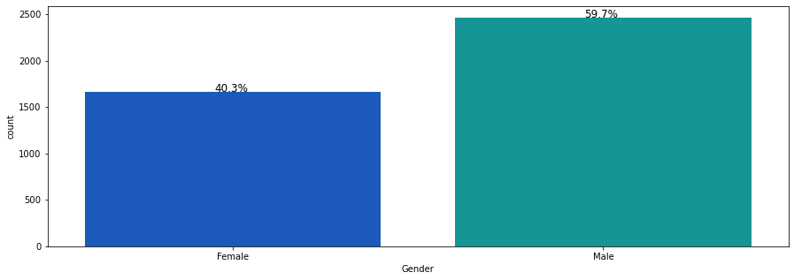

```python
# Countplot of Gender
plt.figure(figsize=(15, 5))
ax = sns.countplot(data["Gender"], palette="winter")
percent(ax, data["Gender"])
```

#### Observations

There is slightly more males in the dataset. I will determine if Gender plays a factor in conversion.

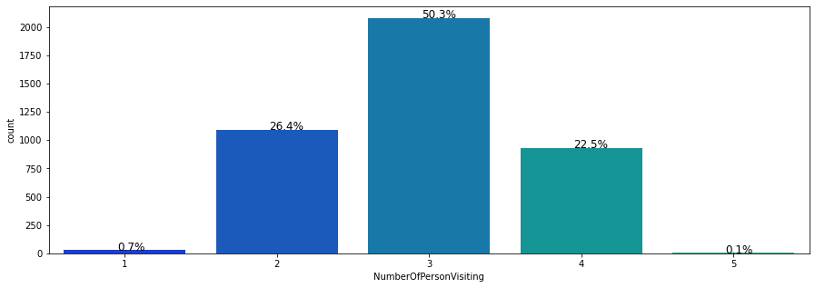

```python
# Countplot of NumberOfPersonVisiting
plt.figure(figsize=(15, 5))
ax = sns.countplot(data["NumberOfPersonVisiting"], palette="winter")
percent(ax, data["NumberOfPersonVisiting"])
```

#### Observations

NumberOfPersonVisiting mainly ranges from 2-4. These three categories take up 99% of the dataset.

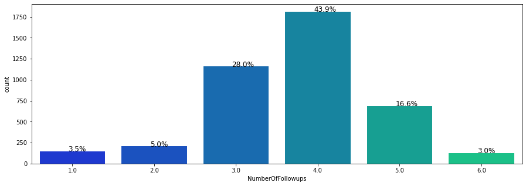

```python
# Countplot of NumberOfFollowups
plt.figure(figsize=(15, 5))
ax = sns.countplot(data["NumberOfFollowups"], palette="winter")
percent(ax, data["NumberOfFollowups"])
```

#### Observations

Most of the dataset is between 3 to 5 followups.

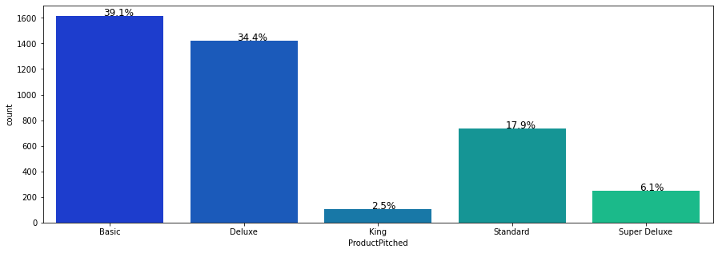

```python
# Countplot of ProductPitched
plt.figure(figsize=(15, 5))
ax = sns.countplot(data["ProductPitched"], palette="winter")
percent(ax, data["ProductPitched"])
```

#### Observations

Basic and deluxe are by far the most pitched between the 5 products.

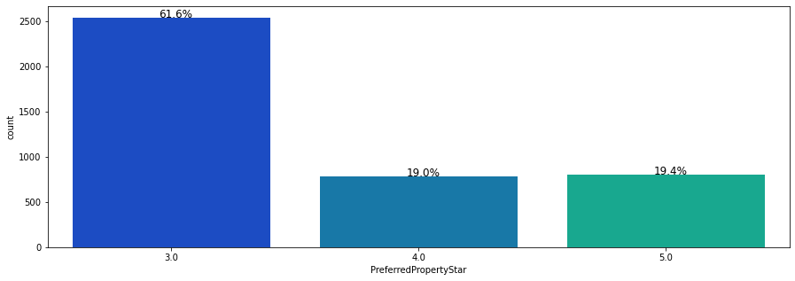

```python
# Countplot of PreferredPropertyStar
plt.figure(figsize=(15, 5))
ax = sns.countplot(data["PreferredPropertyStar"], palette="winter")
percent(ax, data["PreferredPropertyStar"])
```

#### Observations

3 is the most common, occupying three-fifths of the data.

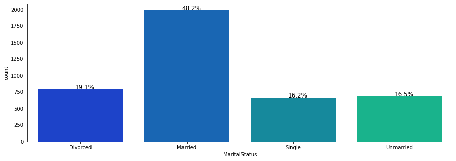

```python
# Countplot of MaritalStatus
plt.figure(figsize=(15, 5))
ax = sns.countplot(data["MaritalStatus"], palette="winter")
percent(ax, data["MaritalStatus"])
```

#### Observations

Married takes up half the dataset, otherwise the other 3 categories are quite even.

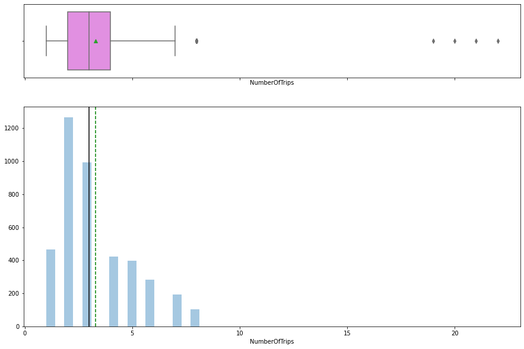

```python
# Histogram showing NumberOfTrips
histogram_boxplot(data["NumberOfTrips"])
```

#### Observations

There are some major outliers in this variable that need some treatment later. There is a right skew, with the mean being greater than the median.

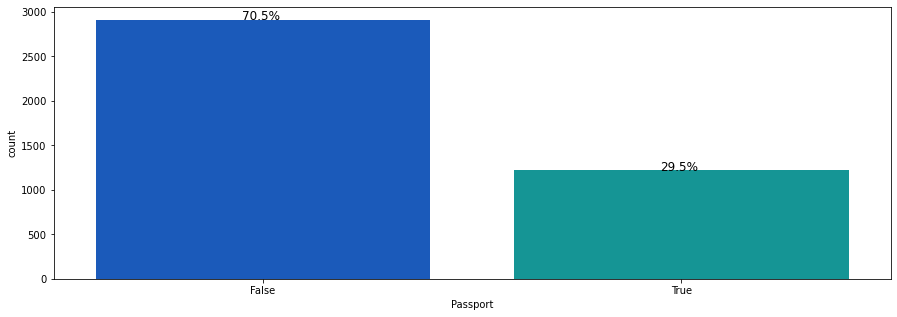

```python
# Countplot of Passport
plt.figure(figsize=(15, 5))
ax = sns.countplot(data["Passport"], palette="winter")
percent(ax, data["Passport"])
```

#### Observations

70% do not have a passport.

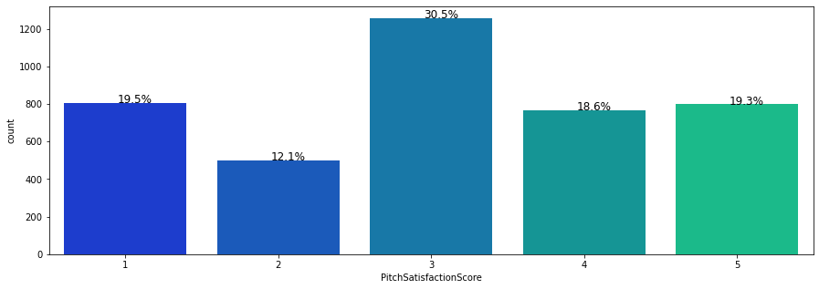

```python
# Countplot of PitchSatisfactionScore
plt.figure(figsize=(15, 5))
ax = sns.countplot(data["PitchSatisfactionScore"], palette="winter")
percent(ax, data["PitchSatisfactionScore"])
```

#### Observations

These variables are quite even.

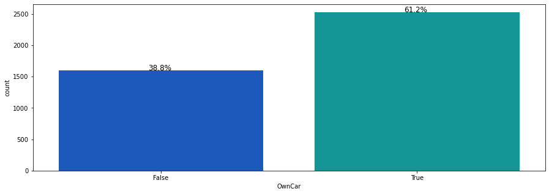

```python
# Countplot of OwnCar
plt.figure(figsize=(15, 5))
ax = sns.countplot(data["OwnCar"], palette="winter")
percent(ax, data["OwnCar"])
```

#### Observations

60% own a car.

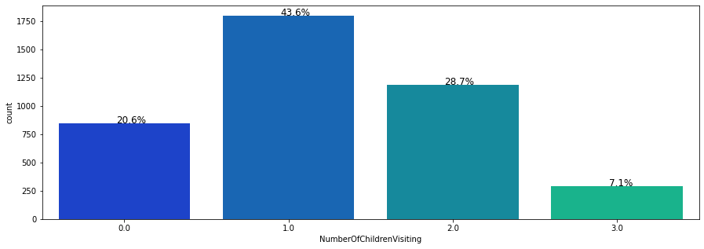

```python
# Countplot of NumberOfChildrenVisiting
plt.figure(figsize=(15, 5))
ax = sns.countplot(data["NumberOfChildrenVisiting"], palette="winter")
percent(ax, data["NumberOfChildrenVisiting"])
```

#### Observations

Most of the dataset is two or less children.

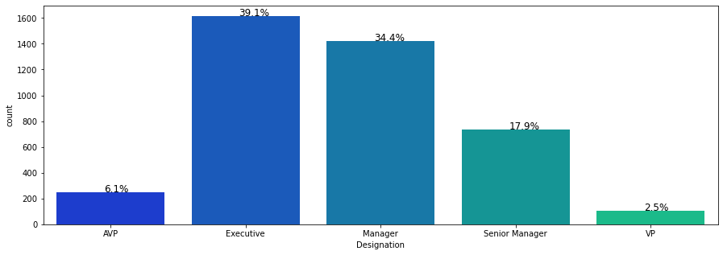

```python
# Countplot of Designation
plt.figure(figsize=(15, 5))
ax = sns.countplot(data["Designation"], palette="winter")
percent(ax, data["Designation"])
```

#### Observations

Executive and managers are the most common designation in the dataset. VP's and AVP's are quite rare.

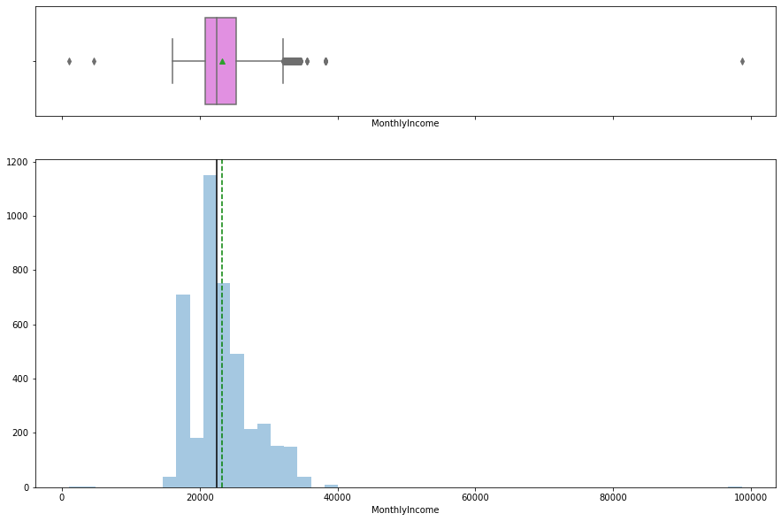

```python
# Histogram showing MonthlyIncome
histogram_boxplot(data["MonthlyIncome"])
```

#### Observations

There are some outliers in Income. I will look at this further in outlier treatment. There is a slight right skew in this variable.

### Multivariate Analysis

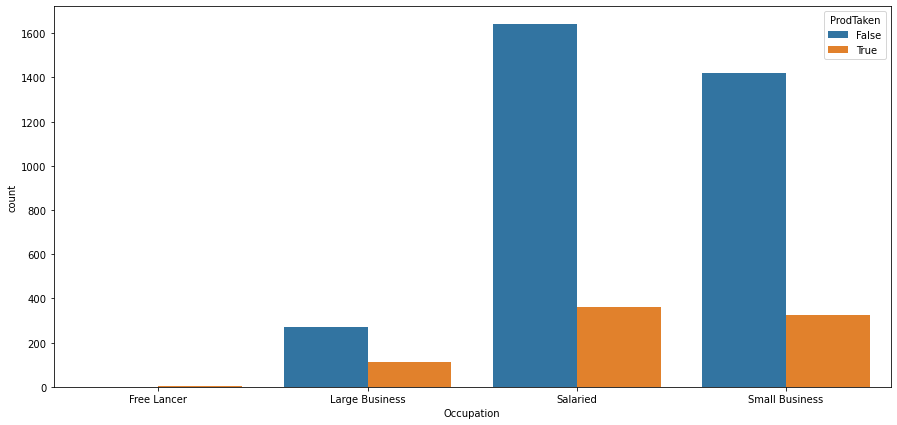

```python
# Countplot of Occupation and ProdTaken
plt.figure(figsize=(15, 7))
sns.countplot(x="Occupation", hue="ProdTaken", data=data)
```

#### Observations

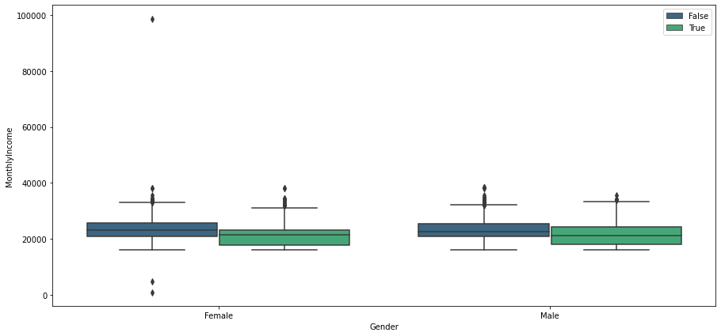

```python
# Boxplot of Gender, MonthlyIncome, and ProductPitched
plt.figure(figsize=(15, 7))
sns.boxplot(
    data["Gender"], data["MonthlyIncome"], hue=data["ProdTaken"], palette="viridis"
)
plt.legend(bbox_to_anchor=(1.00, 1))
plt.show()
```

#### Observations

It appears that Gender is not really an influential variable for the product conversion. They are quite even.

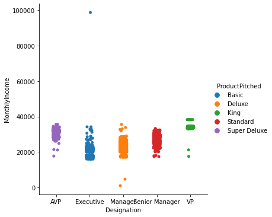

```python
# Boxplot of Designation, Income, and ProductPitched
sns.catplot(
    x="Designation", y="MonthlyIncome", hue="ProductPitched", data=data, kind="strip"
)
```

#### Observations

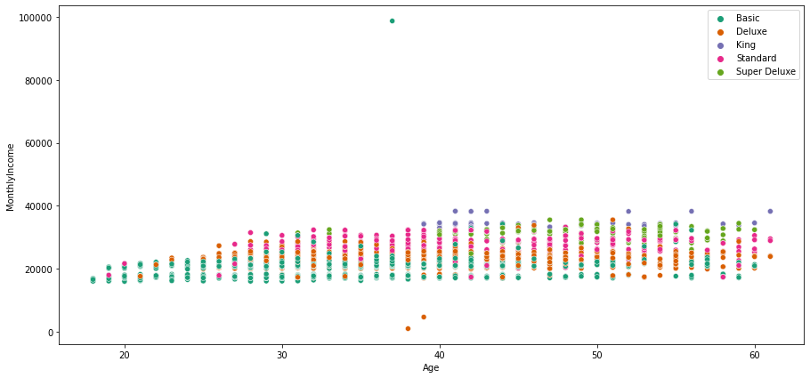

```python
# Scatterplot of Age, Income, and ProductPitched
plt.figure(figsize=(15, 7))
sns.scatterplot(
    data["Age"],
    data["MonthlyIncome"],
    hue=data["ProductPitched"],
    ci=0.0,
    palette="Dark2",
)
plt.legend(bbox_to_anchor=(1.00, 1))
plt.show()
```

#### Observations

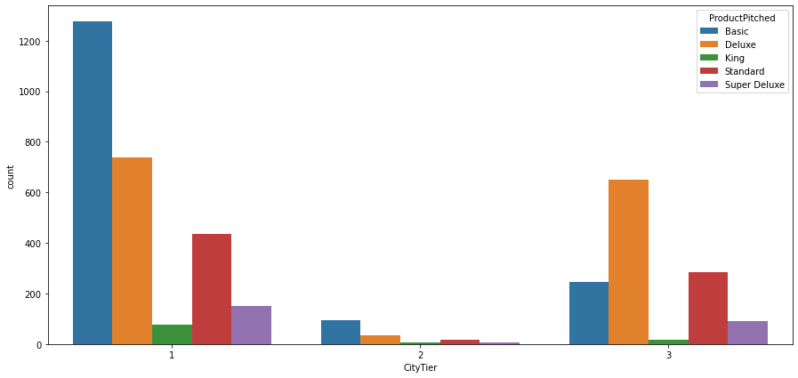

```python
# Countplot of CityTier and ProductPitched
plt.figure(figsize=(15, 7))
sns.countplot(x="CityTier", hue="ProductPitched", data=data)
```

#### Observations

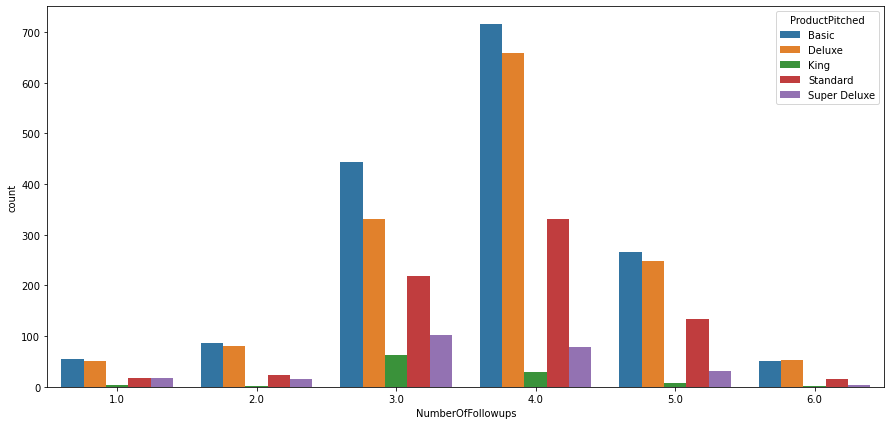

```python
# Countplot of NumberOfFollowups and ProductPitched
plt.figure(figsize=(15, 7))
sns.countplot(x="NumberOfFollowups", hue="ProductPitched", data=data)
```

#### Observations

I see here that the number of followups are rather high fro those who got the basic and deluxe. They needed 3-4 to make the package purchase

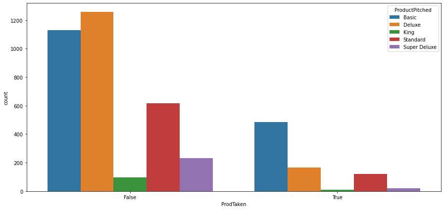

```python
# Countplot of ProdTaken and ProductPitched
plt.figure(figsize=(15, 7))
sns.countplot(x="ProdTaken", hue="ProductPitched", data=data)
```

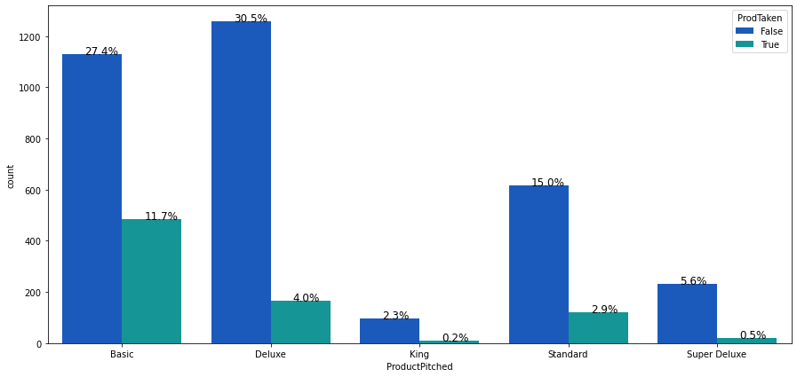

```python
# Using a countplot to show us the proportions in percentage form of conversion for each group
plt.figure(figsize=(15, 7))
ax = sns.countplot(data["ProductPitched"], hue=data["ProdTaken"], palette="winter")
percent(ax, data["ProductPitched"])
```

#### Observations

Here I see the conversion rate amongst the packages. See the end of the notebook for detailed explanation

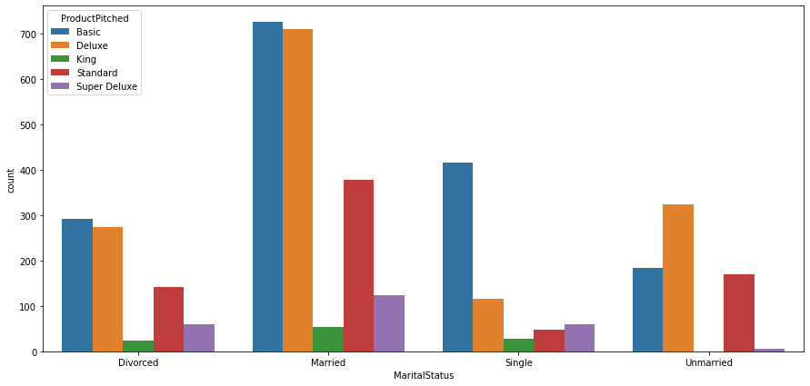

```python
# Using a countplot to show us the Marital Status in relation to ProductPitched
plt.figure(figsize=(15, 7))
ax = sns.countplot(data["MaritalStatus"], hue=data["ProductPitched"])
```

#### Observations

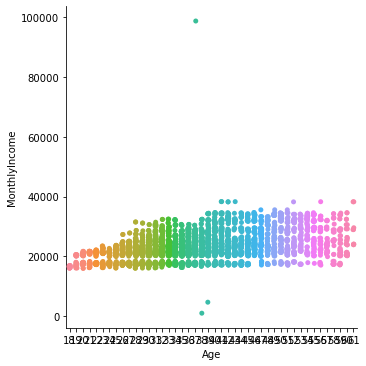

```python
# Boxplot of Age and Income
plt.figure(figsize=(30, 20))
sns.catplot(
    x="Age",
    y="MonthlyIncome",
    data=data,
    kind="strip",
)
```

#### Observations

I see here that as age goes up, so does income

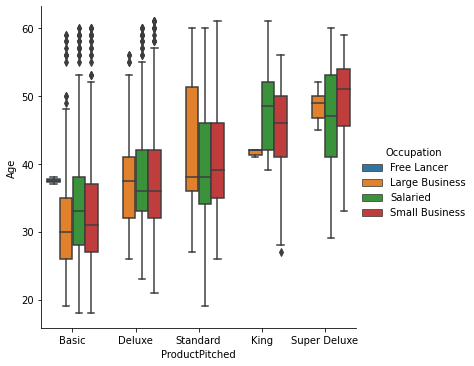

```python
# Boxplot of ProductPitched, Age, and Occupation
sns.catplot(
    x="ProductPitched",
    y="Age",
    hue="Occupation",
    data=data,
    kind="box",
    order=["Basic", "Deluxe", "Standard", "King", "Super Deluxe"],
)
```

#### Observations

I see a positive correlation with age and the type of package purchased. As the older you get, you will purchase a "nicer" package. Income most likely plays into this.

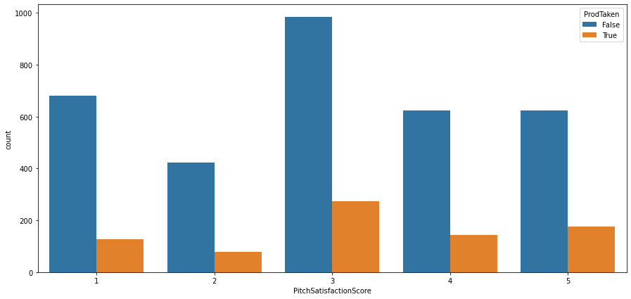

```python
# Using a countplot to show us the Marital Status in relation to ProductPitched
plt.figure(figsize=(15, 7))
ax = sns.countplot(data["PitchSatisfactionScore"], hue=data["ProdTaken"])
```